# Predicting NBA Players Performance

## SVM Regression

```r
#10 fold CV SVM
mse_vec2 <- rep(NA, 10)
for(i in 1:10){
    testIndexes <- which(folds==i,arr.ind=TRUE)
    TestSVM <- modelDFCopy[testIndexes, ]
    TrainSVM <- modelDFCopy[-testIndexes, ]

    svmModel <- train(PPG ~., method = "svmLinear", data = TrainSVM[, c("PPG", xvars)])
    predictions <- predict(svmModel, newdata = TestSVM[, xvars])
    mse_vec2[i] <- mean((TestSVM$PPG-predictions)^2)

}
```

```r
mseDF2 <- data.frame(mse_vec2) %>%
  summarise(MSE = mse_vec2)

rmse3 <- data.frame(RMSE = sqrt(mean(mseDF2$MSE)))
rmse3 %>%
  kable(
    caption = "RMSE of 10 Fold CV SVM Linear Model",
    booktabs = TRUE,
    align = c("l"),
    digits = 4
  ) %>%
  kableExtra::kable_styling(
    bootstrap_options = c("striped", "condensed"),
    font_size = 16
  )
```

RMSE of 10 Fold CV SVM Linear Model

| RMSE |
| --- |
| 2.1997 |

```r
#combining predictions of LM,KNN and SVM models and averaging them
ensemblePred <- (knn_res$pred + predictions + pred) / 3


rmse4 <- data.frame(RMSE = rmse(ensemblePred, Test$PPG))
rmse4 %>%
  kable(
    caption = "RMSE of Ensemble Model Consisting of lm, SVM, and KNN",
    booktabs = TRUE,
    align = c("l"),
    digits = 4
  ) %>%
  kableExtra::kable_styling(
    bootstrap_options = c("striped", "condensed"),
    font_size = 16
  )
```

RMSE of Ensemble Model Consisting of lm, SVM, and KNN

| RMSE |
| --- |
| 2.0292 |

Because I was not familiar with creating an ensemble in r, I used chat GPT to help me make code for the ensemble model.

## Classification

```r
mean(FinalTable1$EFF)
```

```r
#Adding "Good" column (indicator variable) if a players efficiency rating is above average
FinalTable1 <- FinalTable1 %>%
  mutate(Good = ifelse(EFF >= mean(EFF)-.1, 1, 0))
```

```r
glmModelDF <- FinalTable1 %>%
  select(Height, Weight, Wingspan, HandLength, HandWidth, POS, Good) %>%
  na.omit()

model1 <- glm(Good ~ Height + Weight + Wingspan + HandLength + HandWidth + POS, family = binomial, data = glmModelDF)
threshold <- 0.5
pred_prob <- predict(model1, newdata = glmModelDF, type = "response")
pred_surv <- ifelse(pred_prob > threshold, "Yes", "No")
```

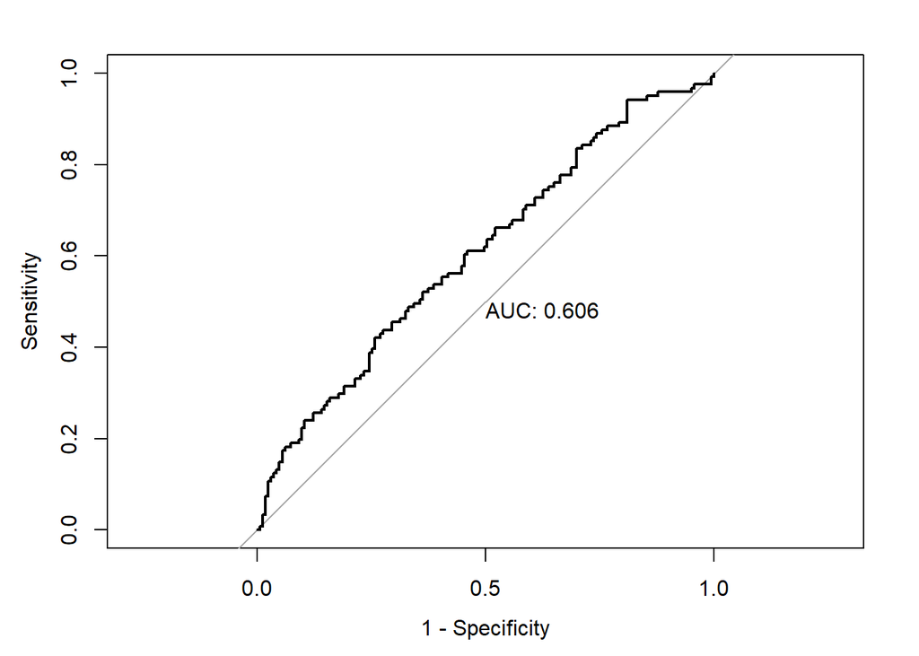

```r
test_roc <- roc(response = glmModelDF$Good,
                predictor = pred_prob,
                plot = TRUE,
                print.auc = TRUE,
                legacy.axes = TRUE)
```

Figure 15: AUC-ROC Curve

In normal circumstances, a AUC of .606 inst good, but it is interesting that given only physical features about a player, there is a 60% chance that you can predict if they will have an above average efficiency rating.